# REPRODUCIBILITY: DATA ANALYSIS

This notebook aims at analysing the games between LLMs and Stockfish (the path of the folder containing the games must be in the `GPTCHESS_GAMES_FOLDER` environment variable), and reproducing the results of the following blog post: https://blog.mathieuacher.com/GPTsChessEloRatingLegalMoves

It also produces a CSV compiling all the games.

You can execute and export this notebook automatically, using the `analysis.Dockerfile` file (cf `README.md`).

# Store the games in a pandas dataframe

```
Folder used: /app/games
```

### Retrieve information from each game

```
No game.pgn in /app/games/game34fad7dd-e598-4969-9ac2-ab745885f0ee
No game.pgn in /app/games/gameb134bc87-b178-4031-a7ef-5d63e85830f6
```

```
No game.pgn in /app/games/gameb8966a66-5767-4b1d-be36-388a6f669efa
```

```
No game.pgn in /app/games/game1503b2e5-e815-49e1-b1bf-14d9b02e3067
```

```
No game.pgn in /app/games/game1a570601-11a1-4bb2-bf14-ba8b4eeef40f
No game.pgn in /app/games/gameda5b7902-6ab2-43f9-8236-79bc9a2e0633
```

```
-> 878/884 games retrieved
```

### Result

|  | white | black | white_elo | black_elo | result | nmoves | nstarting_move | pgn_base | temperature | random_engine | has_illegal | illegal_move | folder_name | pgn_base_moves | base_pgn_prompt |
| --- | --- | --- | --- | --- | --- | --- | --- | --- | --- | --- | --- | --- | --- | --- | --- |
| 0 | Stockfish | text-davinci-003 | 1694 | ? | * | 23 | 1 | [Event "FIDE World Championship Match 2024"]\n... | 0.0 | False | True | Bxd4 | /app/games/game59c83e3f-5ad3-4d64-b697-6ea0095... |  | True |
| 1 | gpt-3.5-turbo-instruct | Stockfish | ? | 1785 | 0-1 | 244 | 1 | [Event "FIDE World Championship Match 2024"]\n... | 0.8 | False | False |  | /app/games/game332c5a22-657d-48da-8c76-8e58262... |  | True |
| 2 | gpt-3.5-turbo-instruct | Stockfish | ? | 1871 | 0-1 | 118 | 1 | [Event "FIDE World Championship Match 2024"]\n... | 0.8 | False | False |  | /app/games/gameb1439fa6-5d7a-439e-a1c7-ecae586... |  | True |
| 3 | Stockfish | gpt-3.5-turbo-instruct | 1785 | ? | 1-0 | 55 | 1 | [Event "FIDE World Championship Match 2024"]\n... | 0.8 | False | False |  | /app/games/gamef427d146-15c9-4221-967d-355af64... |  | True |
| 4 | gpt-4 | RANDOM chess engine | ? | ? | 1-0 | 39 | 1 | It is your turn! You have white pieces. Please... | 0.0 | True | False |  | /app/games/gamed0d94f4b-fba4-4561-acfd-076023c... |  | False |

|  | text-davinci-003 | gpt-3.5-turbo | gpt-4 | gpt-3.5-turbo-instruct |
| --- | --- | --- | --- | --- |
| white | 43 | 53 | 116 | 401 |
| black | 30 | 0 | 63 | 172 |
| total | 73 | 53 | 179 | 573 |

```
Saved at analysis_files/games_db.csv
```

# Analysis of illegal moves

### text-davinci-003 (completion)

A few stats:

```
73 games with davinci
with white pieces 43
with black pieces 30
21 games against random chess engine
72 games with illegal move
score 0.0
The longest game was 20.0 moves
The shortest game was 4.5 moves
The average game length was 12.027397260273972 moves
The median game length was 11.5 moves
the only game with no illegal move is /app/games/game2c08616b-29e3-4728-b19f-2e61eda8d67b
```

### GPTs against random engine

```
ANALYSIS OF gpt-3.5-turbo-instruct, WITH 'random_engine == True':
- 61 total games, with lengths:
```

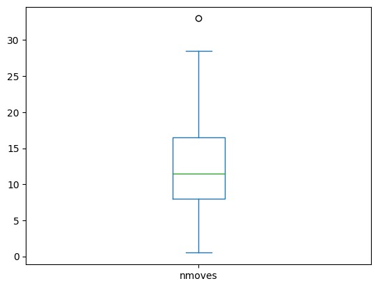

```
- Score 98.89% for games with only legal moves
Score 72.95% for all games i.e. 44.5/61, being legal or illegal (illegal move = loss)
- Out of 61 games, 45 were legal games and 16 were illegal games, hence 26% of illegal games.
Illegal moves are:
| illegal_move   |   count |
|:---------------|--------:|
| hxg8=          |       4 |
| gxh8=          |       3 |
| {[%clk         |       2 |
| {The           |       1 |
| bxc1=          |       1 |
| exf8=          |       1 |
| dxc8=          |       1 |
| cxd8=          |       1 |
| gxh1=          |       1 |
| gxf8=          |       1 |


ANALYSIS OF gpt-3.5-turbo, WITH 'random_engine == True':
- 23 total games, with lengths:
```

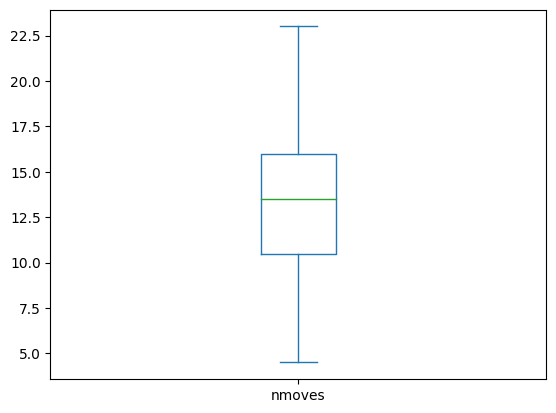

```
- Score 100.0% for games with only legal moves
Score 26.09% for all games i.e. 6.0/23, being legal or illegal (illegal move = loss)
- Out of 23 games, 6 were legal games and 17 were illegal games, hence 74% of illegal games.
Illegal moves are:
| illegal_move   |   count |
|:---------------|--------:|
| fxg7           |       1 |
| Qxd8+          |       1 |
| hxg8=Q         |       1 |
| fxg8=Q         |       1 |
| Bxf8           |       1 |
| Qxf8#          |       1 |
| Bxd6           |       1 |
| Bxg8           |       1 |
| Qd5            |       1 |
| exf6           |       1 |
| Nf7+           |       1 |
| gxh8=Q         |       1 |
| cxd6           |       1 |
| dxe6           |       1 |
| fxg6           |       1 |
| Qe2#           |       1 |
| Nxf6#          |       1 |


ANALYSIS OF gpt-4, WITH 'random_engine == True':
- 85 total games, with lengths:
```

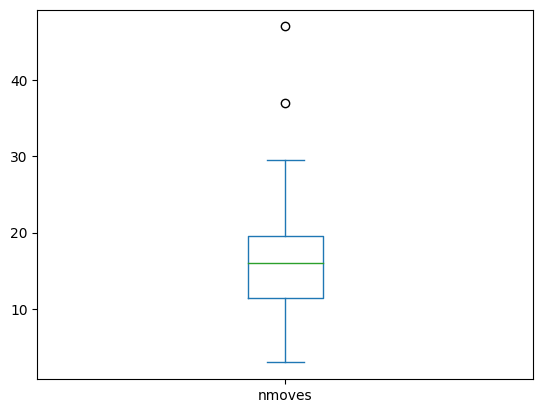

```
- Score 99.15% for games with only legal moves
Score 68.82% for all games i.e. 58.5/85, being legal or illegal (illegal move = loss)
- Out of 85 games, 59 were legal games and 26 were illegal games, hence 31% of illegal games.
Illegal moves are:
| illegal_move   |   count |
|:---------------|--------:|
| 12...          |       2 |
| 9...           |       1 |
| exd8           |       1 |
| Rxg8           |       1 |
| 17...          |       1 |
| 6.             |       1 |
| Qd7            |       1 |
| Qxd8           |       1 |
| Nxg4           |       1 |
| gxh8           |       1 |
| Bxa6           |       1 |
| Qd4            |       1 |
| Qh5            |       1 |
| Qae8#          |       1 |
| 16...          |       1 |
| exd2+          |       1 |
| 5.             |       1 |
| 14...          |       1 |
| cxd8           |       1 |
| fxg7           |       1 |
| Qh4#           |       1 |
| Qxc8#          |       1 |
| Bxf8           |       1 |
| Qd5+           |       1 |
| gxh7+          |       1 |
```

### GPTs against SF

```
ANALYSIS OF gpt-3.5-turbo-instruct, WITH 'random_engine == False and nstarting_move <= 2':
- 439 total games, with lengths:
```

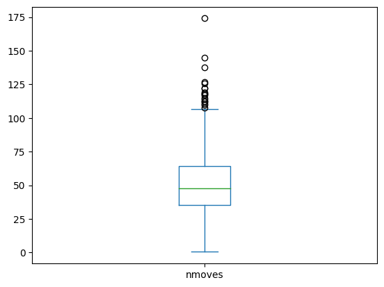

```
- Score 38.48% for games with only legal moves
Score 32.35% for all games i.e. 142.0/439, being legal or illegal (illegal move = loss)
- Out of 439 games, 369 were legal games and 70 were illegal games, hence 16% of illegal games.
Illegal moves are:
| illegal_move   |   count |
|:---------------|--------:|
| 1-0            |      49 |
| 1-             |       4 |
| Kb3            |       1 |
| {(Leko-G       |       1 |
| {[%clk         |       1 |
| gxh8=          |       1 |
| {This          |       1 |
| Nxa3           |       1 |
| bxc8=          |       1 |
| axb8=          |       1 |
| dxe8=          |       1 |
| bxc3           |       1 |
| cxb8=          |       1 |
| exf8=          |       1 |
| {M.            |       1 |
| Rxh5           |       1 |
| f7             |       1 |
| Qa7            |       1 |
| {The           |       1 |


ANALYSIS OF gpt-3.5-turbo, WITH 'random_engine == False and nstarting_move <= 2':
- 30 total games, with lengths:
```

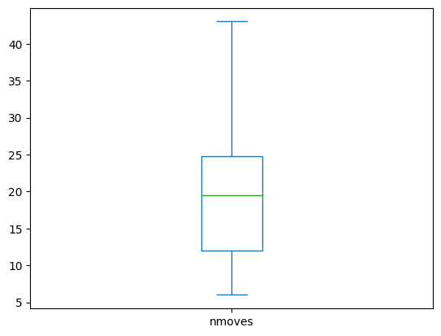

```
- Score 0.0% for games with only legal moves
Score 0.0% for all games i.e. 0.0/30, being legal or illegal (illegal move = loss)
- Out of 30 games, 2 were legal games and 28 were illegal games, hence 93% of illegal games.
Illegal moves are:
| illegal_move   |   count |
|:---------------|--------:|
| Qxe4           |       2 |
| cxb7           |       2 |
| cxd6           |       1 |
| Rxh1           |       1 |
| Bxc6           |       1 |
| Nxd1           |       1 |
| Bg8            |       1 |
| Nxe5+          |       1 |
| Qxf6           |       1 |
| Qxf5           |       1 |
| Qxg5           |       1 |
| Rxf6           |       1 |
| Rxf7+          |       1 |
| Nxe1           |       1 |
| Bxf6           |       1 |
| exd6           |       1 |
| Rxh6           |       1 |
| Bh4            |       1 |
| Kxe1           |       1 |
| Rd8            |       1 |
| exf6           |       1 |
| Nxf7+          |       1 |
| Bxd6+          |       1 |
| Bxh6           |       1 |
| O-O            |       1 |
| c4             |       1 |


ANALYSIS OF gpt-4, WITH 'random_engine == False and nstarting_move <= 2':
- 94 total games, with lengths:
```

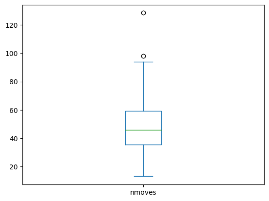

```
- Score 7.03% for games with only legal moves
Score 4.79% for all games i.e. 4.5/94, being legal or illegal (illegal move = loss)
- Out of 94 games, 64 were legal games and 30 were illegal games, hence 32% of illegal games.
Illegal moves are:
| illegal_move   |   count |
|:---------------|--------:|
| Kxd6           |       1 |
| Rd1+           |       1 |
| Kxf5           |       1 |
| Kd8            |       1 |
| Bg2            |       1 |
| Bxa7           |       1 |
| Kxe6           |       1 |
| Re8+           |       1 |
| Rxa4           |       1 |
| Qe5+           |       1 |
| Rd7            |       1 |
| Kxc4           |       1 |
| Kxf3           |       1 |
| Bxf6           |       1 |
| Bxf7           |       1 |
| Checkmate!     |       1 |
| Rd3            |       1 |
| Kxb5           |       1 |
| Qxh3           |       1 |
| Rxe8           |       1 |
| Nxb6           |       1 |
| Rxh1           |       1 |
| Kg3            |       1 |
| Kg1.           |       1 |
| gxh6           |       1 |
| Bb7            |       1 |
| b5             |       1 |
| Kb6            |       1 |
| Kd2            |       1 |
| Ke4            |       1 |
```

### Focus on GPT 3.5 turbo-instruct's illegal moves against SF

It appears that the vast majority on its illegal moves are "1-0", indicating that it may resign as black, probably in worse positions. We can put this hypothesis to the test by evaluating these positions with Stockfish:

```
|    | GPT Color   | Assessment   |
|---:|:------------|:-------------|
|  0 | Black       | 6.74         |
|  1 | Black       | 0.0          |
|  2 | Black       | Mate in 3    |
|  3 | Black       | 6.38         |
|  4 | Black       | Mate in 1    |
|  5 | Black       | 6.93         |
|  6 | Black       | Mate in 1    |
|  7 | Black       | 5.48         |
|  8 | Black       | 7.79         |
|  9 | Black       | Mate in 1    |
| 10 | Black       | 10.52        |
| 11 | Black       | 6.34         |
| 12 | Black       | 3.73         |
| 13 | Black       | 35.81        |
| 14 | Black       | 5.51         |
| 15 | Black       | Mate in 1    |
| 16 | Black       | Mate in 4    |
| 17 | Black       | Mate in 1    |
| 18 | Black       | 6.97         |
| 19 | Black       | Mate in 1    |
| 20 | Black       | Mate in 5    |
| 21 | Black       | Mate in 3    |
| 22 | Black       | 10.46        |
| 23 | Black       | Mate in 9    |
| 24 | Black       | 5.22         |
| 25 | Black       | 5.64         |
| 26 | Black       | 6.79         |
| 27 | Black       | 6.39         |
| 28 | Black       | -0.41        |
| 29 | Black       | 3.63         |
| 30 | Black       | 6.39         |
| 31 | Black       | 5.83         |
| 32 | Black       | Mate in 4    |
| 33 | Black       | 34.74        |
| 34 | Black       | 5.72         |
| 35 | White       | Mate in -1   |
| 36 | Black       | 6.81         |
| 37 | Black       | Mate in 2    |
| 38 | Black       | 6.23         |
| 39 | Black       | Mate in 7    |
| 40 | Black       | 7.16         |
| 41 | Black       | 6.17         |
| 42 | Black       | 6.64         |
| 43 | Black       | 7.71         |
| 44 | Black       | Mate in 2    |
| 45 | Black       | -1.54        |
| 46 | Black       | Mate in 2    |
| 47 | Black       | Mate in 1    |
| 48 | Black       | Mate in 1    |
```

Conclusion: Indeed, "1-0" is a correct continuation (even though it is not technically a chess move), since it means black resigns the game. Moreover, this decision is often very logical, since it occurs in positions where white is dominating.

# Elo rating of GPTs against SF

### Overall GPTs' performances

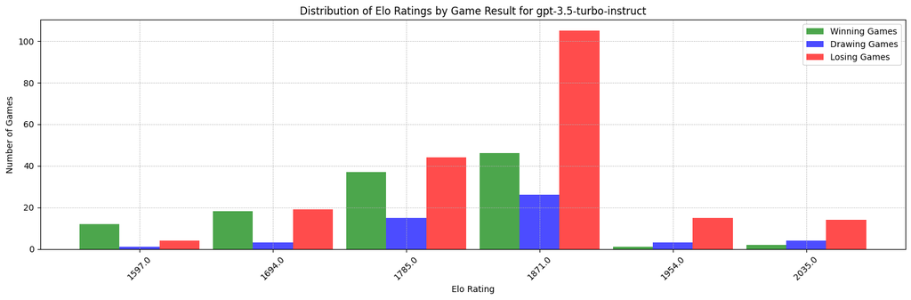

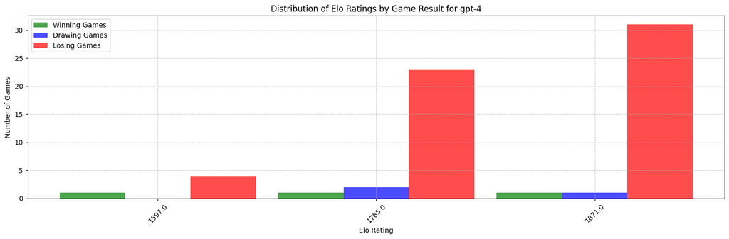

### Influence of the prompt on win rates:

- With the based prompt:

[Event "FIDE World Championship Match 2024"] [Site "Los Angeles, USA"] [Date "2024.12.01"] [Round "5"] [White "Carlsen, Magnus"] [Black "Nepomniachtchi, Ian"] [Result "1-0"] [WhiteElo "2885"] [WhiteTitle "GM"] [WhiteFideId "1503014"] [BlackElo "2812"] [BlackTitle "GM"] [BlackFideId "4168119"] [TimeControl "40/7200:20/3600:900+30"] [UTCDate "2024.11.27"] [UTCTime "09:01:25"] [Variant "Standard"] 1.

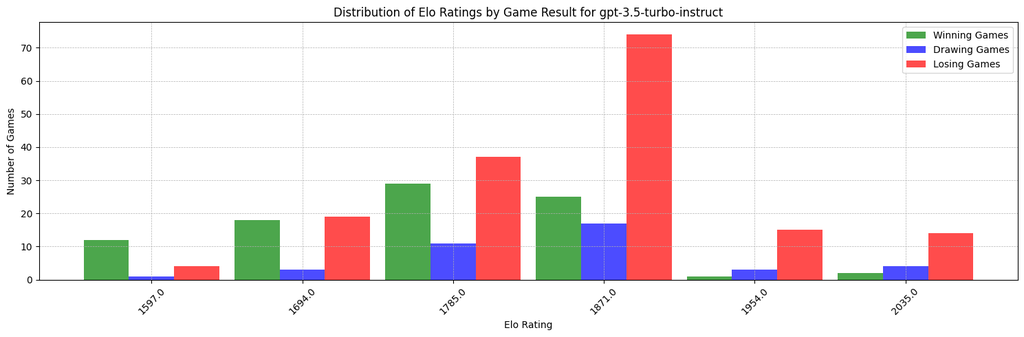

- With the altered prompt:

[Event "Chess tournament"] [Site "Rennes FRA"] [Date "2023.12.09"] [Round "7"] [White "MVL, Magnus"] [Black "Ivanchuk, Ian"] [Result "1-0"] [WhiteElo "2737"] [BlackElo "2612"] 1.

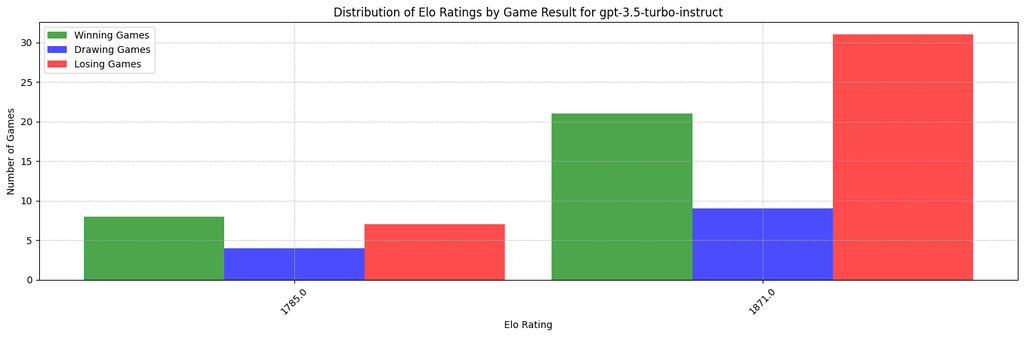

### GPT 3.5 turbo-instruct's elo

```
ELO OF gpt-3.5-turbo-instruct, WITH 'nstarting_move <= 2 and temperature == 0.0 and has_illegal==False':
1789
ELO OF gpt-3.5-turbo-instruct, WITH 'nstarting_move <= 2 and temperature == 0.0':
1742
ELO OF gpt-3.5-turbo-instruct, WITH 'nstarting_move <= 2 and temperature == 0.2 and has_illegal==False':
1071
ELO OF gpt-3.5-turbo-instruct, WITH 'nstarting_move <= 2 and temperature == 0.2':
1071
ELO OF gpt-3.5-turbo-instruct, WITH 'nstarting_move <= 2 and temperature == 0.8 and has_illegal==False':
1572
ELO OF gpt-3.5-turbo-instruct, WITH 'nstarting_move <= 2 and temperature == 0.8':
1518
```

### GPT 3.5 turbo's elo

```
ELO OF gpt-3.5-turbo, WITH 'nstarting_move <= 2 and temperature == 0.0 and has_illegal==False':
1071
ELO OF gpt-3.5-turbo, WITH 'nstarting_move <= 2 and temperature == 0.0':
988
```

### GPT 4's elo

```
ELO OF gpt-4, WITH 'nstarting_move <= 2 and temperature == 0.0 and has_illegal==False':
1393
ELO OF gpt-4, WITH 'nstarting_move <= 2 and temperature == 0.0':
1336
```

# Conclusion:

GPT 3.5 turbo-instructs shows a much better chess understanding than its pears (3.5 turbo, 4), both in terms of ELO and illegal moves. If we consider illegal games as losses, it has an ELO rating of 1742.

Due to the opacity of these models, we can only speculate as to the reasons why this happens: maybe the dataset used for its training contains more PGNs, or the fine-tuning for chat decreased this ability for GPT 3.5 turbo and GPT 4.